# Binary Classification Model for Census Income Using Python Take 2

### July 30, 2018

Template Credit: Adapted from a template made available by Dr. Jason Brownlee of Machine Learning Mastery. https://machinelearningmastery.com/

SUMMARY: The purpose of this project is to construct a prediction model using various machine learning algorithms and to document the end-to-end steps using a template. The Census Income dataset is a classic binary classification situation where we are trying to predict one of the two possible outcomes.

INTRODUCTION: This data was extracted from the 1994 Census Bureau database by Ronny Kohavi and Barry Becker (Data Mining and Visualization, Silicon Graphics). A set of reasonably clean records was extracted using the following conditions: ((AAGE>16) && (AGI>100) && (AFNLWGT>1) && (HRSWK>0)). The prediction task is to determine whether a person makes over 50K a year.

This dataset has many cells with missing values, so we will examine the models by imputing the missing cells with a default value. This iteration of the project will produce a set of results that we will use to compare with the baseline models from Take 1.

CONCLUSION: From the previous iteration (Take 1), The baseline performance of the ten algorithms achieved an average accuracy of 81.37%. Four ensemble algorithms (Bagged CART, Random Forest, AdaBoost, and Stochastic Gradient Boosting) achieved the top accuracy scores after the first round of modeling. After a series of tuning trials, Stochastic Gradient Boosting turned in the top result using the training data. It achieved an average accuracy of 86.99%. Using the optimized tuning parameter available, the Stochastic Gradient Boosting algorithm further processed the validation dataset with an accuracy of 87.23%, which was slightly better than the accuracy of the training data.

From this iteration (Take 2), the baseline performance of the ten algorithms achieved an average accuracy of 81.93%. Four ensemble algorithms (Bagged CART, Random Forest, AdaBoost, and Stochastic Gradient Boosting) achieved the top accuracy scores after the first round of modeling. After a series of tuning trials, Stochastic Gradient Boosting turned in the top result using the training data. It achieved an average accuracy of 87.31%. Using the optimized tuning parameter available, the Stochastic Gradient Boosting algorithm further processed the validation dataset with an accuracy of 87.57%, which was slightly better than the accuracy of the training data.

For this project, imputing the missing values appeared to have contributed to a slight improvement of the overall accuracy of the training model. The Stochastic Gradient Boosting ensemble algorithm continued to yield consistently top-notch training and validation results, which warrant the additional processing required by the algorithm.

Dataset Used: Census Income Data Set

Dataset ML Model: Binary classification with numerical and categorical attributes

Dataset Reference: https://archive.ics.uci.edu/ml/datasets/Census+Income

One potential source of performance benchmark: https://www.kaggle.com/uciml/adult-census-income

The project aims to touch on the following areas:

- Document a predictive modeling problem end-to-end.
- Explore data cleaning and transformation options
- Explore non-ensemble and ensemble algorithms for baseline model performance
- Explore algorithm tuning techniques for improving model performance

Any predictive modeling machine learning project genrally can be broken down into about six major tasks:

1. Prepare Problem
2. Summarize Data
3. Prepare Data
4. Model and Evaluate Algorithms
5. Improve Accuracy or Results
6. Finalize Model and Present Results

## Section 1 - Prepare Problem

### 1.a) Load ibraries

```python
import numpy as np
import pandas as pd
from matplotlib import pyplot
#from pandas import read_csv
#from pandas import set_option
#from pandas import get_dummies
#from pandas.plotting import scatter_matrix
from sklearn.preprocessing import StandardScaler
from sklearn.model_selection import train_test_split
from sklearn.model_selection import KFold
from sklearn.model_selection import cross_val_score
from sklearn.model_selection import GridSearchCV
from sklearn.metrics import classification_report
from sklearn.metrics import confusion_matrix
from sklearn.metrics import accuracy_score
from sklearn.pipeline import Pipeline
from sklearn.linear_model import LogisticRegression
from sklearn.tree import DecisionTreeClassifier
from sklearn.neighbors import KNeighborsClassifier
from sklearn.discriminant_analysis import LinearDiscriminantAnalysis
from sklearn.naive_bayes import GaussianNB
from sklearn.svm import SVC
from sklearn.ensemble import BaggingClassifier
from sklearn.ensemble import RandomForestClassifier
from sklearn.ensemble import ExtraTreesClassifier
from sklearn.ensemble import AdaBoostClassifier
from sklearn.ensemble import GradientBoostingClassifier
from sklearn.externals.joblib import dump
from sklearn.externals.joblib import load
from datetime import datetime
```

### 1.b) Load dataset

```python
startTimeScript = datetime.now()

inputFile = 'adult.data'
colNames = ['age', 'workclass', 'fnlwgt', 'education', 'education-num', 'marital-status', 'occupation', 'relationship', 'race', 'sex', 'capital-gain', 'capital-loss', 'hours-per-week', 'native-country', 'income']
entireDataset = pd.read_csv(inputFile, na_values='?', names=colNames, delimiter=' *, *', engine='python')

inputFile = 'adult.test'
colNames = ['age', 'workclass', 'fnlwgt', 'education', 'education-num', 'marital-status', 'occupation', 'relationship', 'race', 'sex', 'capital-gain', 'capital-loss', 'hours-per-week', 'native-country', 'income']
testDataset = pd.read_csv(inputFile, na_values='?', names=colNames, delimiter=' *, *', engine='python')

# Standardize the class column to the name of targetVar
entireDataset = entireDataset.rename(columns={'income': 'targetVar'})
testDataset = testDataset.rename(columns={'income': 'targetVar'})
```

## Section 2 - Summarize Data

To gain a better understanding of the data that we have on-hand, we will leverage a number of descriptive statistics and data visualization techniques. The plan is to use the results to consider new questions, review assumptions, and validate hypotheses that we can investigate later with specialized models.

### 2.a) Descriptive statistics

```python
# Set up a variable for the total number of attribute columns (totAttr)
totCol = len(entireDataset.columns)
totAttr = totCol-1
# Set up the number of row and columns for visualization display. dispRow * dispCol should be >= totAttr
dispCol = 3
if totAttr % dispCol == 0 :
    dispRow = totAttr // dispCol
else :
    dispRow = (totAttr // dispCol) + 1
```

#### 2.a.i) Peek at the data itself.

```python
pd.set_option('display.width', 100)
print(entireDataset.head(20))
```

```
    age         workclass  fnlwgt     education  education-num         marital-status  \
0    39         State-gov   77516     Bachelors             13          Never-married
1    50  Self-emp-not-inc   83311     Bachelors             13     Married-civ-spouse
2    38           Private  215646       HS-grad              9               Divorced
3    53           Private  234721          11th              7     Married-civ-spouse
4    28           Private  338409     Bachelors             13     Married-civ-spouse
5    37           Private  284582       Masters             14     Married-civ-spouse
6    49           Private  160187           9th              5  Married-spouse-absent
7    52  Self-emp-not-inc  209642       HS-grad              9     Married-civ-spouse
8    31           Private   45781       Masters             14          Never-married
9    42           Private  159449     Bachelors             13     Married-civ-spouse
10   37           Private  280464  Some-college             10     Married-civ-spouse
11   30         State-gov  141297     Bachelors             13     Married-civ-spouse
12   23           Private  122272     Bachelors             13          Never-married
13   32           Private  205019    Assoc-acdm             12          Never-married
```

[output cut: 50 more lines]

#### 2.a.ii) Dimensions of the dataset.

```python
print(entireDataset.shape)
```

```
(32561, 15)
```

```python
print(testDataset.shape)
```

```
(16281, 15)
```

#### 2.a.iii) Types of the attributes.

```python
print(entireDataset.dtypes)
```

```
age                int64
workclass         object
fnlwgt             int64
education         object
education-num      int64
marital-status    object
occupation        object
relationship      object
race              object
sex               object
capital-gain       int64
capital-loss       int64
hours-per-week     int64
native-country    object
targetVar         object
dtype: object
```

#### 2.a.iv) Statistical summary of all attributes.

```python
print(entireDataset.describe())
```

```
                age        fnlwgt  education-num  capital-gain  capital-loss  hours-per-week
count  32561.000000  3.256100e+04   32561.000000  32561.000000  32561.000000    32561.000000
mean      38.581647  1.897784e+05      10.080679   1077.648844     87.303830       40.437456
std       13.640433  1.055500e+05       2.572720   7385.292085    402.960219       12.347429
min       17.000000  1.228500e+04       1.000000      0.000000      0.000000        1.000000
25%       28.000000  1.178270e+05       9.000000      0.000000      0.000000       40.000000
50%       37.000000  1.783560e+05      10.000000      0.000000      0.000000       40.000000
75%       48.000000  2.370510e+05      12.000000      0.000000      0.000000       45.000000
max       90.000000  1.484705e+06      16.000000  99999.000000   4356.000000       99.000000
```

#### 2.a.v) Summarize the levels of the class attribute.

```python
print(entireDataset.groupby('targetVar').size())
```

```
targetVar
<=50K    24720
>50K      7841
dtype: int64
```

#### 2.a.v) Count missing values.

```python
print(entireDataset.isnull().sum())
```

```
age                  0
workclass         1836
fnlwgt               0
education            0
education-num        0
marital-status       0
occupation        1843
relationship         0
race                 0
sex                  0
capital-gain         0
capital-loss         0
hours-per-week       0
native-country     583
targetVar            0
dtype: int64
```

```python
print(testDataset.isnull().sum())
```

```
age                 0
workclass         963
fnlwgt              0
education           0
education-num       0
marital-status      0
occupation        966
relationship        0
race                0
sex                 0
capital-gain        0
capital-loss        0
hours-per-week      0
native-country    274
targetVar           0
dtype: int64
```

### 2.b) Data visualizations

##### 2.b.i) Univariate plots to better understand each attribute

```python
# Set figure width to 16 and height to 12 (4:3 aspect ratio)
fig_size = pyplot.rcParams["figure.figsize"]
fig_size[0] = 16
fig_size[1] = 12
pyplot.rcParams["figure.figsize"] = fig_size
```

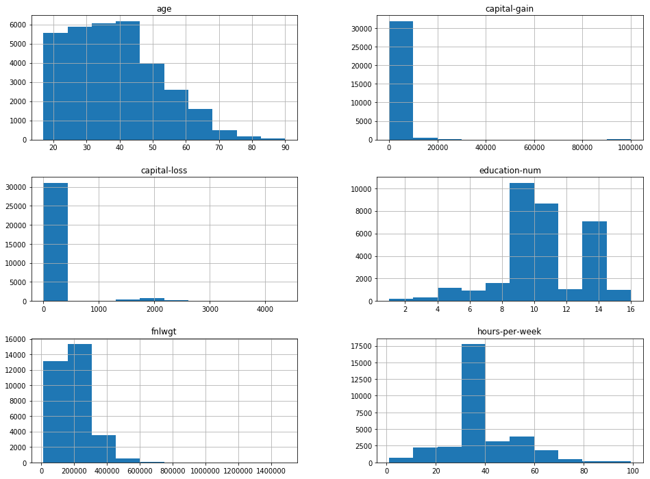

```python
# Histograms for each attribute
entireDataset.hist()
pyplot.show()
```

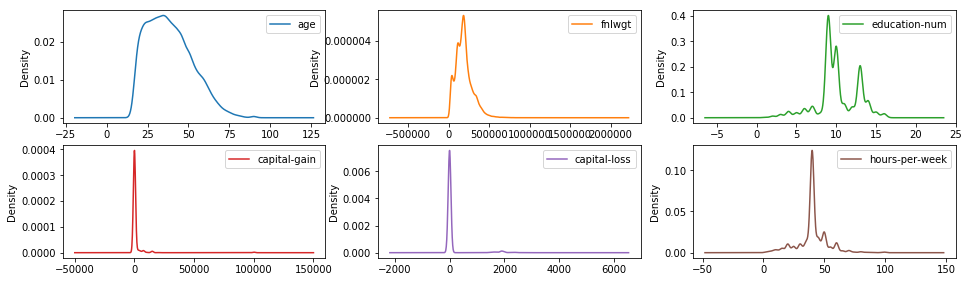

```python
# Density plot for each attribute
entireDataset.plot(kind='density', subplots=True, layout=(dispRow,dispCol), sharex=False)
pyplot.show()
```

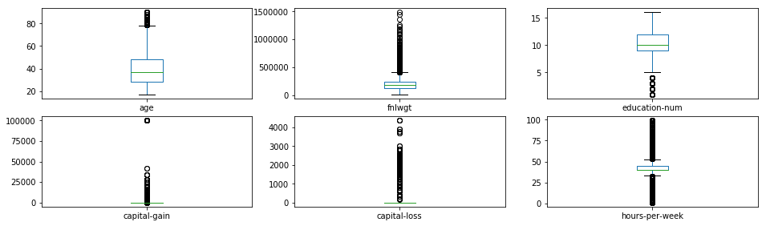

```python
# Box and Whisker plot for each attribute
entireDataset.plot(kind='box', subplots=True, layout=(dispRow,dispCol), sharex=False, sharey=False)
pyplot.show()
```

#### 2.b.ii) Multivariate plots to better understand the relationships between attributes

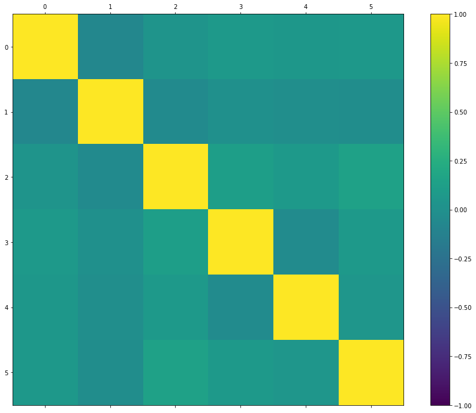

```python
# Correlation matrix
fig = pyplot.figure()
ax = fig.add_subplot(111)
cax = ax.matshow(entireDataset.corr(), vmin=-1, vmax=1)
fig.colorbar(cax)
pyplot.show()
```

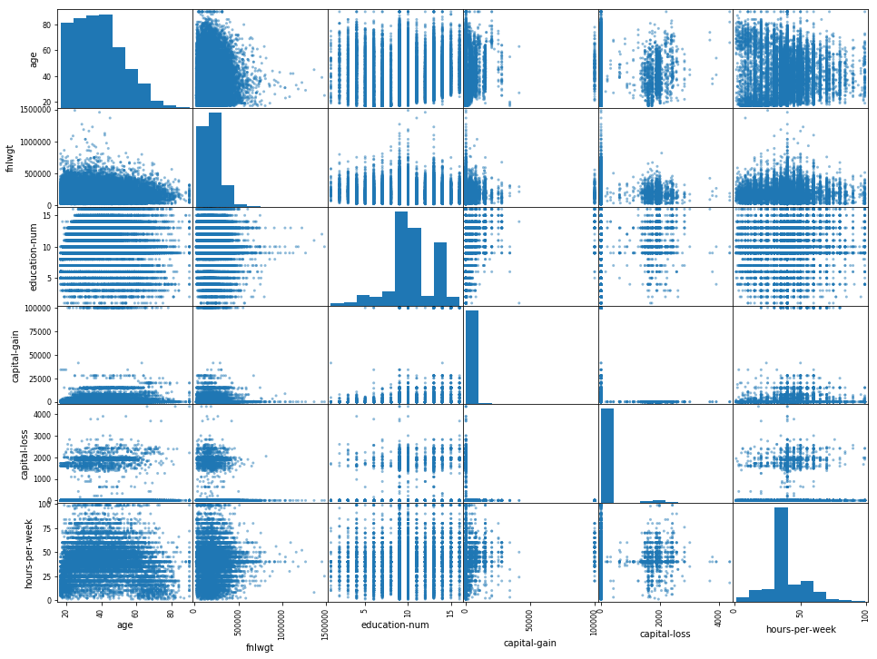

```python
# Scatterplot matrix
pd.plotting.scatter_matrix(entireDataset)
pyplot.show()
```

## Section 3 - Prepare Data

Some dataset may require additional preparation activities that will best exposes the structure of the problem and the relationships between the input attributes and the output variable. Some data-prep tasks might include:

- Cleaning data by removing duplicates, marking missing values and even imputing missing values.
- Feature selection where redundant features may be removed.
- Data transforms where attributes are scaled or redistributed in order to best expose the structure of the problem later to learning algorithms.

### 3.a) Data Cleaning

```python
# eliminate the missing cells by deleting the data rows
entireDataset.fillna('Not-disclosed',inplace=True)
print(entireDataset.isnull().sum())
```

```
age               0
workclass         0
fnlwgt            0
education         0
education-num     0
marital-status    0
occupation        0
relationship      0
race              0
sex               0
capital-gain      0
capital-loss      0
hours-per-week    0
native-country    0
targetVar         0
dtype: int64
```

```python
print(entireDataset.shape)
```

```
(32561, 15)
```

```python
print(entireDataset.groupby('targetVar').size())
```

```
targetVar
<=50K    24720
>50K      7841
dtype: int64
```

```python
# eliminate the missing cells by deleting the data rows
testDataset.fillna('Not-disclosed',inplace=True)
print(testDataset.isnull().sum())
```

```
age               0
workclass         0
fnlwgt            0
education         0
education-num     0
marital-status    0
occupation        0
relationship      0
race              0
sex               0
capital-gain      0
capital-loss      0
hours-per-week    0
native-country    0
targetVar         0
dtype: int64
```

```python
print(testDataset.shape)
```

```
(16281, 15)
```

```python
print(testDataset.groupby('targetVar').size())
```

```
targetVar
<=50K.    12435
>50K.      3846
dtype: int64
```

### 3.b) Feature Selection

```python
# Not applicable for this iteration of the project.
```

### 3.c) Data Transforms

```python
# Apply the One-Hot-Encoding (Dummy Variables) technique to both datasets
# Before we carry out OHE, we will combine both training and test datasets together.
# By perform HOE on one, combined dataset, we ensure consistency of the column layout for both datasets
trainingDataset = entireDataset
trainingRows = len(trainingDataset)
testRows = len(testDataset)
print(trainingRows, testRows)
entireDataset = pd.concat([entireDataset, testDataset])
print(entireDataset.shape)
entireDataset_dummies = pd.get_dummies(entireDataset)

# As it turned out, the training and test datasets had slightly different class labels.
# The training dataset had <=50K and >50K, where the test dataset had <=50K. and >50K. (with extra period).
# We need to make sure both datasets labels the classes the same way.
entireDataset_dummies['targetVar_>50K'] = np.where(entireDataset_dummies['targetVar_>50K.']==1, 1, entireDataset_dummies['targetVar_>50K'])
entireDataset_dummies['targetVar'] = entireDataset_dummies['targetVar_>50K']
entireDataset_dummies.pop('targetVar_<=50K')
entireDataset_dummies.pop('targetVar_>50K')
entireDataset_dummies.pop('targetVar_<=50K.')
entireDataset_dummies.pop('targetVar_>50K.')
print(entireDataset_dummies.dtypes)
```

```
32561 16281
(48842, 15)
age                                          int64
fnlwgt                                       int64
education-num                                int64
capital-gain                                 int64
capital-loss                                 int64
hours-per-week                               int64
workclass_Federal-gov                        uint8
workclass_Local-gov                          uint8
workclass_Never-worked                       uint8
workclass_Not-disclosed                      uint8
workclass_Private                            uint8
workclass_Self-emp-inc                       uint8
workclass_Self-emp-not-inc                   uint8
workclass_State-gov                          uint8
workclass_Without-pay                        uint8
education_10th                               uint8
education_11th                               uint8
education_12th                               uint8
education_1st-4th                            uint8
education_5th-6th                            uint8
education_7th-8th                            uint8
education_9th                                uint8
education_Assoc-acdm                         uint8
education_Assoc-voc                          uint8
education_Bachelors                          uint8
education_Doctorate                          uint8
education_HS-grad                            uint8
education_Masters                            uint8
education_Preschool                          uint8
education_Prof-school                        uint8
                                             ...
native-country_Haiti                         uint8
native-country_Holand-Netherlands            uint8
native-country_Honduras                      uint8
native-country_Hong                          uint8
native-country_Hungary                       uint8
native-country_India                         uint8
native-country_Iran                          uint8
```

[output cut: 9 more lines]

```
native-country_Peru                          uint8
native-country_Philippines                   uint8
native-country_Poland                        uint8
native-country_Portugal                      uint8
native-country_Puerto-Rico                   uint8
native-country_Scotland                      uint8
native-country_South                         uint8
native-country_Taiwan                        uint8
native-country_Thailand                      uint8
native-country_Trinadad&Tobago               uint8
native-country_United-States                 uint8
native-country_Vietnam                       uint8
native-country_Yugoslavia                    uint8
targetVar                                    uint8
Length: 109, dtype: object
```

```python
# After One-Hot-Encoding and making sure all columns are properly labeled, we slice the dataset into two again.
trainingDataset_dummies = entireDataset_dummies[0:trainingRows]
print(trainingDataset_dummies.shape)
testDataset_dummies = entireDataset_dummies[trainingRows:(trainingRows+testRows)]
print(testDataset_dummies.shape)
```

```
(32561, 109)
(16281, 109)
```

### 3.d) Split-out training and validation datasets

We create a training dataset (variable name "training") and a validation dataset (variable name "validation").

```python
seedNum = 777
totCol = len(trainingDataset_dummies.columns)
array = trainingDataset_dummies.values
X_train = array[:,0:totCol-1]
Y_train = array[:,totCol-1]
totCol = len(testDataset_dummies.columns)
array = testDataset_dummies.values
X_validation = array[:,0:totCol-1]
Y_validation = array[:,totCol-1]
print("X_train.shape: {} Y_train.shape: {}".format(X_train.shape, Y_train.shape))
print("X_validation.shape: {} Y_validation.shape: {}".format(X_validation.shape, Y_validation.shape))
print ('Total time for data handling and visualization:',(datetime.now() - startTimeScript))
```

```
X_train.shape: (32561, 108) Y_train.shape: (32561,)
X_validation.shape: (16281, 108) Y_validation.shape: (16281,)
Total time for data handling and visualization: 0:00:28.680718
```

## 4. Model and Evaluate Algorithms

After the data-prep, we next work on finding a workable model by evaluating a subset of machine learning algorithms that are good at exploiting the structure of the training. The typical evaluation tasks include:

- Defining test options such as cross validation and the evaluation metric to use.
- Spot checking a suite of linear and nonlinear machine learning algorithms.
- Comparing the estimated accuracy of algorithms.

For this project, we will evaluate one linear, four non-linear and five ensemble algorithms:

Linear Algorithm: Logistic Regression

Non-Linear Algorithms: Decision Trees (CART), Naive Bayes, k-Nearest Neighbors, and Support Vector Machine

Ensemble Algorithms: Bagged CART, Random Forest, Extra Trees, AdaBoost, and Stochastic Gradient Boosting

The random number seed is reset before each run to ensure that the evaluation of each algorithm is performed using the same data splits. It ensures the results are directly comparable.

### 4.a) Set test options and evaluation metric

```python
# Run algorithms using 10-fold cross validation
num_folds = 10
scoring = 'accuracy'
```

```python
# Set up Algorithms Spot-Checking Array
models = []
models.append(('LR', LogisticRegression(random_state=seedNum)))
models.append(('CART', DecisionTreeClassifier(random_state=seedNum)))
models.append(('NB', GaussianNB()))
models.append(('KNN', KNeighborsClassifier()))
models.append(('SVM', SVC(random_state=seedNum)))
models.append(('BT', BaggingClassifier(random_state=seedNum)))
models.append(('RF', RandomForestClassifier(random_state=seedNum)))
models.append(('ET', ExtraTreesClassifier(random_state=seedNum)))
models.append(('AB', AdaBoostClassifier(random_state=seedNum)))
models.append(('GBM', GradientBoostingClassifier(random_state=seedNum)))
results = []
names = []
metrics = []
```

```python
# Generate model in turn
for name, model in models:
	startTimeModule = datetime.now()
	kfold = KFold(n_splits=num_folds, random_state=seedNum)
	cv_results = cross_val_score(model, X_train, Y_train, cv=kfold, scoring=scoring)
	results.append(cv_results)
	names.append(name)
	metrics.append(cv_results.mean())
	msg = "%s: %f (%f)" % (name, cv_results.mean(), cv_results.std())
	print(msg)
	print ('Model training time:',(datetime.now() - startTimeModule))
print ('Average metrics ('+scoring+') from all models:',np.mean(metrics))
```

```
LR: 0.797457 (0.005513)
Model training time: 0:00:01.851404
CART: 0.817113 (0.006920)
Model training time: 0:00:07.176092
NB: 0.795307 (0.005200)
Model training time: 0:00:01.040348
KNN: 0.776758 (0.005574)
Model training time: 0:00:15.588537
SVM: 0.756058 (0.005072)
Model training time: 1:11:10.924356
BT: 0.848654 (0.006653)
Model training time: 0:00:21.472607
RF: 0.846074 (0.005388)
Model training time: 0:00:05.958081
ET: 0.829582 (0.005462)
Model training time: 0:00:07.986329
AB: 0.860477 (0.006458)
Model training time: 0:00:30.548469
GBM: 0.865913 (0.004990)
Model training time: 0:01:36.932880
Average metrics (accuracy) from all models: 0.8193393411205048
```

### 4.b) Spot-checking baseline algorithms

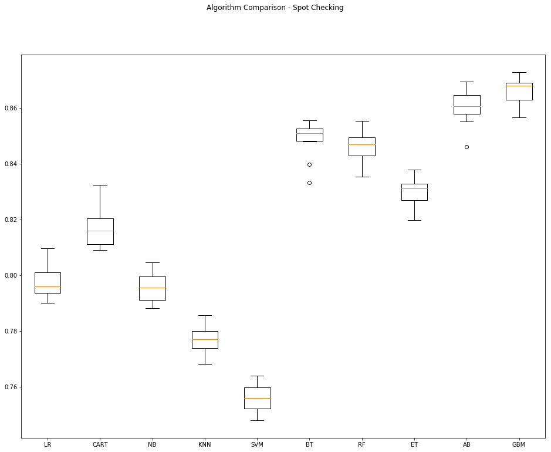

```python
fig = pyplot.figure()
fig.suptitle('Algorithm Comparison - Spot Checking')
ax = fig.add_subplot(111)
pyplot.boxplot(results)
ax.set_xticklabels(names)
pyplot.show()
```

## Section 5 - Improve Accuracy

After we achieve a short list of machine learning algorithms with good level of accuracy, we can leverage ways to improve the accuracy of the models.

### 5.a) Algorithm Tuning

```python
# Set up the comparison array
results = []
names = []
```

```python
# Tuning algorithm #1 - Bagged CART
startTimeModule = datetime.now()
paramGrid1 = dict(n_estimators=np.array([300,500,700,800,900]))
model1 = BaggingClassifier(random_state=seedNum)
kfold = KFold(n_splits=num_folds, random_state=seedNum)
grid1 = GridSearchCV(estimator=model1, param_grid=paramGrid1, scoring=scoring, cv=kfold)
grid_result1 = grid1.fit(X_train, Y_train)

print("Best: %f using %s" % (grid_result1.best_score_, grid_result1.best_params_))
results.append(grid_result1.cv_results_['mean_test_score'])
names.append('BT')
means = grid_result1.cv_results_['mean_test_score']
stds = grid_result1.cv_results_['std_test_score']
params = grid_result1.cv_results_['params']
for mean, stdev, param in zip(means, stds, params):
    print("%f (%f) with: %r" % (mean, stdev, param))
print ('Model training time:',(datetime.now() - startTimeModule))
```

```
Best: 0.857283 using {'n_estimators': 800}
0.856730 (0.006942) with: {'n_estimators': 300}
0.856853 (0.006239) with: {'n_estimators': 500}
0.856761 (0.005961) with: {'n_estimators': 700}
0.857283 (0.006074) with: {'n_estimators': 800}
0.857130 (0.006179) with: {'n_estimators': 900}
Model training time: 2:10:17.871968
```

```python
# Tuning algorithm #2 - Random Forest
startTimeModule = datetime.now()
paramGrid2 = dict(n_estimators=np.array([300,500,700,800,900]))
model2 = RandomForestClassifier(random_state=seedNum)
kfold = KFold(n_splits=num_folds, random_state=seedNum)
grid2 = GridSearchCV(estimator=model2, param_grid=paramGrid2, scoring=scoring, cv=kfold)
grid_result2 = grid2.fit(X_train, Y_train)

print("Best: %f using %s" % (grid_result2.best_score_, grid_result2.best_params_))
results.append(grid_result2.cv_results_['mean_test_score'])
names.append('RF')
means = grid_result2.cv_results_['mean_test_score']
stds = grid_result2.cv_results_['std_test_score']
params = grid_result2.cv_results_['params']
for mean, stdev, param in zip(means, stds, params):
    print("%f (%f) with: %r" % (mean, stdev, param))
print ('Model training time:',(datetime.now() - startTimeModule))
```

```
Best: 0.855348 using {'n_estimators': 500}
0.854458 (0.005856) with: {'n_estimators': 300}
0.855348 (0.006322) with: {'n_estimators': 500}
0.854918 (0.006955) with: {'n_estimators': 700}
0.854765 (0.006730) with: {'n_estimators': 800}
0.854980 (0.006867) with: {'n_estimators': 900}
Model training time: 0:34:27.300178
```

```python
# Tuning algorithm #3 - Stochastic Gradient Boosting
startTimeModule = datetime.now()
paramGrid3 = dict(n_estimators=np.array([250,400,550,700,850]))
model3 = GradientBoostingClassifier(random_state=seedNum)
kfold = KFold(n_splits=num_folds, random_state=seedNum)
grid3 = GridSearchCV(estimator=model3, param_grid=paramGrid3, scoring=scoring, cv=kfold)
grid_result3 = grid3.fit(X_train, Y_train)

print("Best: %f using %s" % (grid_result3.best_score_, grid_result3.best_params_))
results.append(grid_result3.cv_results_['mean_test_score'])
names.append('GBM')
means = grid_result3.cv_results_['mean_test_score']
stds = grid_result3.cv_results_['std_test_score']
params = grid_result3.cv_results_['params']
for mean, stdev, param in zip(means, stds, params):
    print("%f (%f) with: %r" % (mean, stdev, param))
print ('Model training time:',(datetime.now() - startTimeModule))
```

```
Best: 0.873130 using {'n_estimators': 700}
0.870674 (0.005270) with: {'n_estimators': 250}
0.872977 (0.005264) with: {'n_estimators': 400}
0.873008 (0.004981) with: {'n_estimators': 550}
0.873130 (0.005626) with: {'n_estimators': 700}
0.872762 (0.005355) with: {'n_estimators': 850}
Model training time: 0:40:40.387252
```

```python
# Tuning algorithm #4 - AdaBoost
startTimeModule = datetime.now()
paramGrid4 = dict(n_estimators=np.array([250,400,550,700,850]))
model4 = AdaBoostClassifier(random_state=seedNum)
kfold = KFold(n_splits=num_folds, random_state=seedNum)
grid4 = GridSearchCV(estimator=model4, param_grid=paramGrid4, scoring=scoring, cv=kfold)
grid_result4 = grid4.fit(X_train, Y_train)

print("Best: %f using %s" % (grid_result4.best_score_, grid_result4.best_params_))
results.append(grid_result4.cv_results_['mean_test_score'])
names.append('AB')
means = grid_result4.cv_results_['mean_test_score']
stds = grid_result4.cv_results_['std_test_score']
params = grid_result4.cv_results_['params']
for mean, stdev, param in zip(means, stds, params):
    print("%f (%f) with: %r" % (mean, stdev, param))
print ('Model training time:',(datetime.now() - startTimeModule))
```

```
Best: 0.871472 using {'n_estimators': 850}
0.868493 (0.005020) with: {'n_estimators': 250}
0.870090 (0.005030) with: {'n_estimators': 400}
0.870735 (0.004786) with: {'n_estimators': 550}
0.871226 (0.004496) with: {'n_estimators': 700}
0.871472 (0.004874) with: {'n_estimators': 850}
Model training time: 0:30:49.034568
```

### 5.b) Compare Algorithms After Tuning

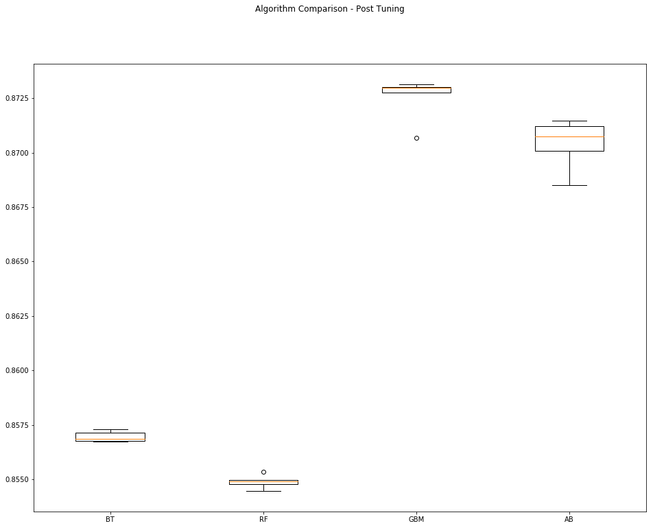

```python
fig = pyplot.figure()
fig.suptitle('Algorithm Comparison - Post Tuning')
ax = fig.add_subplot(111)
pyplot.boxplot(results)
ax.set_xticklabels(names)
pyplot.show()
```

## Section 6 - Finalize Model

Once we have narrow down to a model that we believe can make accurate predictions on unseen data, we are ready to finalize it. Finalizing a model may involve sub-tasks such as:

- Using an optimal model tuned to make predictions on unseen data.
- Creating a standalone model using the tuned parameters
- Saving an optimal model to file for later use.

### 6.a) Predictions on validation dataset

```python
model = GradientBoostingClassifier(n_estimators=700, random_state=seedNum)
model.fit(X_train, Y_train)
predictions = model.predict(X_validation)
print(accuracy_score(Y_validation, predictions))
print(confusion_matrix(Y_validation, predictions))
print(classification_report(Y_validation, predictions))
```

```
0.875744733124501
[[11721   714]
 [ 1309  2537]]
             precision    recall  f1-score   support

          0       0.90      0.94      0.92     12435
          1       0.78      0.66      0.71      3846

avg / total       0.87      0.88      0.87     16281
```

### 6.b) Create standalone model on entire training dataset

```python
startTimeModule = datetime.now()
finalModel = GradientBoostingClassifier(n_estimators=700, random_state=seedNum)
finalModel.fit(X_train, Y_train)
print ('Model training time:',(datetime.now() - startTimeModule))
```

```
Model training time: 0:00:51.115105
```

### 6.c) Save model for later use

```python
# modelName = 'finalModel_BinaryClass.sav'
# dump(finalModel, modelName)

print ('Total time for the script:',(datetime.now() - startTimeScript))
```

```
Total time for the script: 5:12:45.149822
```